# Read Data and Preprocess

**First read the file into program. And prepare each column as a data of list.**

```python
import numpy as np
import warnings
warnings.filterwarnings('ignore')
f = open("stroopdata.csv")
data = [[float(line.split(',')[0]), float(line.split(',')[1])] for line in f.readlines()[1:]]
congruent = [x[0] for x in data]
incongruent = [x[1] for x in data]
print "The first column have "+str(len(congruent))+" numbers."
print "The second column have "+str(len(incongruent))+" numbers."
```

```
The first column have 24 numbers.
The second column have 24 numbers.
```

# Dependent and Independent Variables

**As we can see, the data contains two columns of data which are correspending to two tested cases in this experiment. There are 24 numbers in each column which are corresponding to 24 subjects in the research. These 24 subjects are tested in two cases. And these two cases as a binary variable is independent variable.**

Case 1. Subjects are shown words of color to which are painted corresponding. For example, red, blue and black.

Case 2, Subjects are shown words of color to which are painted corresponding not. For example, blue, red and black.

We will refer the paint of the word as inks and the word itself as word. We refer case 1 as congruent case and case 2 as incongruent case.

The length of time is measured for each subject naming the inks of a list of words which both in congruent and incongruent cases. The length of time as a numeric variable is dependent variable.

# Hypothesis and Satistical Test

**The main question associated with this dataset is if there exists a difference for people making reaction with congruent and incongruent situations. The people's reaction is measured by length of time in which subjects identify the inks of a list of words. We expected length of time to be different for people recognizing inks of congruent and incongruent list of words. This is general idea of my hypothesis test. Here is the detail.**

I will use uc for length of time for normal people which means general population to take naming the inks in congruent words list and ui for length of time for normal people which means general population to take naming the inks in incongruent words list. These parameters in hypothesis test are for whole population.

Null Hypothesis: uc = ui. The length of times are the same for general people. The difference in the samples is due to random fluctuation and the length of time is not dependent on type of the words list(congruent and incongruent).

Alternative Hypothesis: uc < ui. The time naming the inks in incongruent words list is longer than that in congruent words for general people. The time for people identify inks of words is dependent on type of the words list(congruent and incongruent). I eliminate the hypothesis in which uc > ui intuitively. Because prior knowledge about recognizing inks of words indicate that this is highly unlikely.

I choose T-test of difference of times for this hypothesis. Because the sample is paired. That is every subject is exposed to two conditions. And the number of sample is relatively small. Dependent t-test is appropriate for this.

# Exploratory Data Analysis

```python
print "The average, variance and standard deviation of length of time for congruent list is \n"+str(np.mean(congruent))+", " + str(np.var(congruent)) + " and " + str(np.std(congruent)) + "."
print "The average, variance and standard deviation of length of time for incongruent list is \n"+str(np.mean(incongruent))+", " + str(np.var(incongruent)) + " and " + str(np.std(incongruent)) + "."
```

```
The average, variance and standard deviation of length of time for congruent list is
14.051125, 12.1411528594 and 3.48441571277.
The average, variance and standard deviation of length of time for incongruent list is
22.0159166667, 22.0529338264 and 4.69605513451.
```

**Mean, variance the and stand deviation of difference of two times is also calculated. The average difference is positive which is 7.96479166667.**

```python
difference = [x[1] - x[0] for x in data]
```

```python
print "The average, variance and standard deviation of difference of time is \n"+str(np.mean(difference))+", " + str(np.var(difference, ddof  =1)) + " and " + str(np.std(difference, ddof  =1)) + "."
```

```
The average, variance and standard deviation of difference of time is
7.96479166667, 23.6665408678 and 4.86482691036.
```

**The histogram and box-plot of length of time for congruent and incongruent are shown below. The centre of incongruent list is clearly highly deviated from that of congruent list.**

```
WARNING: pylab import has clobbered these variables: ['norm', 'f']
`%matplotlib` prevents importing * from pylab and numpy
```

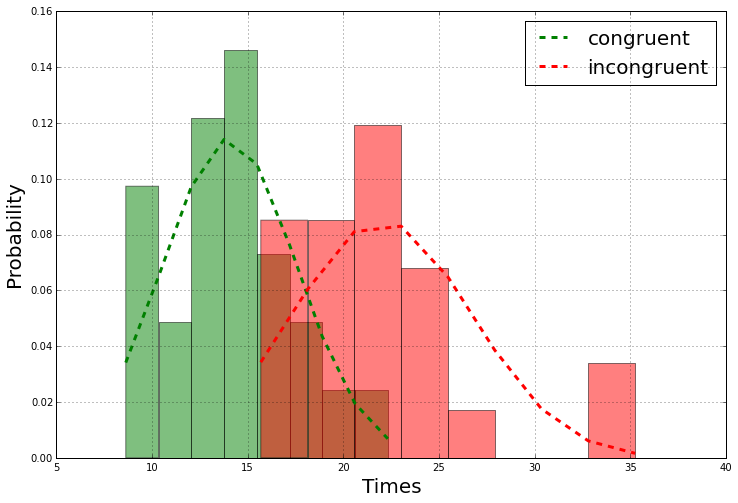

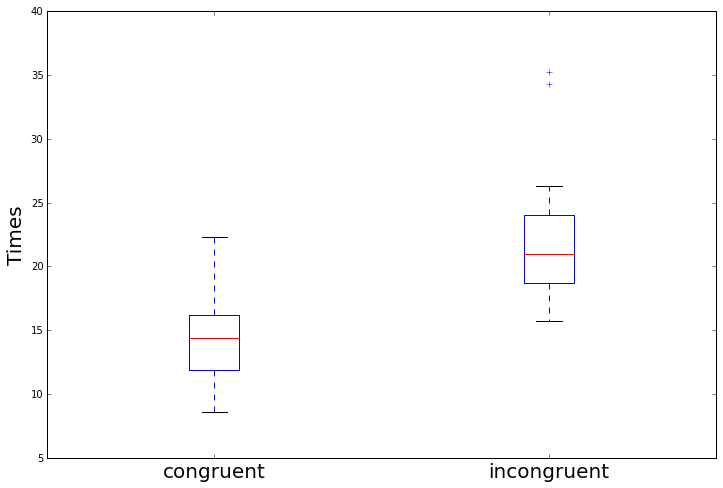

```python
%pylab inline
import matplotlib.mlab as mlab
import matplotlib.pyplot as plt
from scipy.stats import norm
pylab.rcParams['figure.figsize'] = 12, 8
fs = 20
(mu_c, sigma_c) = norm.fit(congruent)
(mu_i, sigma_i) = norm.fit(incongruent)
n, bins, patches = plt.hist(congruent, 8, normed=1, facecolor='green', alpha=0.5)
y = mlab.normpdf( bins, mu_c, sigma_c)
l = plt.plot(bins, y, 'g--', linewidth=3)
n, bins, patches = plt.hist(incongruent, 8, normed=1, facecolor='red', alpha=0.5)
y = mlab.normpdf( bins, mu_i, sigma_i)
l = plt.plot(bins, y, 'r--', linewidth=3)
plt.xlabel('Times',size=fs)
plt.ylabel('Probability',size=fs)
plt.legend(('congruent', 'incongruent'),prop={'size':fs})
plt.grid(True)
plt.show()

plt.boxplot([congruent, incongruent], labels = ['congruent', 'incongruent'])
plt.xticks([1, 2], ['congruent', 'incongruent'], size=fs )
plt.ylabel('Times',size=fs)
plt.show()
```

# Results of Statistical Test

**This is a t-test of difference, I set alpha level at 0.01. Here is calculation result of this test:**

Alpha level: 0.01

Mean: 7.965

Number of Sample: 24

Degree of Freedom: 23

Standard Deviation: 4.864

Margin of Error: 0.993

T-statistics: 8.021

This result showed that people may have slower reaction for incongruent list of words.

# Some Theory And Thoughts

**I think the reason for this is mainly that brain are trained to process the most informative object. First, colors or inks in this article are not as informative as words. There are far less number of types of color than number of words. From information theory, rarer a thing happens, more informative the thing is. A word is more informative than a color in most case for people. Second, our brain are trained to filter the less informative signal. For example, many of us would not notice the noise of car when we are in a car. But we can process voice of human in the car. That is bacause our brain is trained to filter out the noise. In this case, because inks(or color) appeared as less informative information than words. Brain will automatically process words rather than inks. In incongruent test, the result of this process will conflict to the inks. This confliction makes subjects altered the result to accommodate the inks of words. This alteration causes the delay of identifying inks.**

This automatical filter system developed by brain is the need for human to adapt outer world. The information(voice, image, smell and etc.) from the world will overwhelm human. If people can not automatically process information. As my opinion, this ability is developed rather than natural born.

To verify my theory, a lot serious work should be done. First, test if color is less informative than words. Second, test brain will automatically process more informative information after be trained. I only do an experiment to demonstrate my thoughts.

I calculated the relative delay of the time for people to identify the inks in incongruent list.

```python
relative_difference = [(x[1] - x[0])/x[0] for x in data]
print "The average, standard deviation, margin of error and 95% Confidence Interval of relatively delay is \n"+str(np.mean(relative_difference))+", " + str(np.std(relative_difference, ddof  =1)) + " and " + str(np.std(relative_difference, ddof  =1)/sqrt(24)) + "."
```

```
The average, standard deviation, margin of error and 95% Confidence Interval of relatively delay is
0.634162107237, 0.423156176913 and 0.086376392912.
```

**Some statistics about this relative relay:**

Mean: 0.634

Standard Deviation: 0.423

Margin of Error: 0.086

I have done the experiment myself. For congruent list I used 15.756s, and incongruent 34.345s. My relative delay is 1.1798. This may due to English is not my first languange. It takes time for me to remember words corresponding to the inks in incongruent list. However, it is very interesting for my son who is 4 years old and know nothing about English to completed the test. He used 51.947s to complete congruent list and 41.087s to complete incongruent list. His relative delay is -0.20. This is far less than common level. Because he don't know English, these words mean nothing to him. The only information he recieved is color itself.His brain don't recognize words as more informative. So he will not encounter the confliction in which normal people who familiar with English words will be. He can speak the inks in in congruent list as fast as in congruent list.

Formal study must be conducted to analysis the reason of stroop effect. This is only a thought and little experiment.